## Homework 5

Set the location of the working files.

```r
setwd("~/documents/PSY441/CapstoneReproducibility/05 t-tests")
```

Load in the data.

```r
dat<-read.csv("homework5.csv")
```

Look at the structure of the data.

```r
str(dat)
```

```
## 'data.frame':    64 obs. of  2 variables:
##  $ music: Factor w/ 2 levels "metal","none": 2 2 2 2 2 2 2 2 2 2 ...
##  $ wpm  : num  23.5 44.1 42.3 24.4 42.8 ...
```

We can see that dat is a data frame with two variables of music: metal and none. Find the mean words per minute for the two groups.

```r
mean(dat$wpm[dat$music=="metal"])
```

```
## [1] 48.03665
```

```r
mean(dat$wpm[dat$music=="none"])
```

```
## [1] 42.44641
```

By looking at the means it appears that the metal group had more words per minute than the group with no music.

Run an independent t-test to determine if the mean wpm for the metal music group is different from the mean wpm of the no music group.

```r
t.test(dat$wpm[dat$music=="metal"],
       dat$wpm[dat$music=="none"],
       var.equal=TRUE)
```

```
##
##  Two Sample t-test
##
## data:  dat$wpm[dat$music == "metal"] and dat$wpm[dat$music == "none"]
## t = 2.3317, df = 62, p-value = 0.02298
## alternative hypothesis: true difference in means is not equal to 0
## 95 percent confidence interval:
##   0.7977514 10.3827312
## sample estimates:
## mean of x mean of y
##  48.03665  42.44641
```

The results of the t-test show that the participants of the metal music group typed more words per minute than the participants of the no music group, t(62) = 2.33, p = .0230. Run an independent t-test with the alternative hypothesis that the metal music group is faster than the no music group.

```r
t.test(dat$wpm[dat$music=="metal"],
       dat$wpm[dat$music=="none"],
       var.equal=TRUE,
       alternative="greater")
```

```
##
##  Two Sample t-test
##
## data:  dat$wpm[dat$music == "metal"] and dat$wpm[dat$music == "none"]
## t = 2.3317, df = 62, p-value = 0.01149
## alternative hypothesis: true difference in means is greater than 0
## 95 percent confidence interval:
##  1.586923      Inf
## sample estimates:
## mean of x mean of y
##  48.03665  42.44641
```

The results of the t-test show that participants in the metal music group typed faster than participants in the no music group, t(62) = 2.33, p = .0115.

To create a figure of the data I need to load the ggplot2, gplots, and dplyr libraries.

```r
library(ggplot2)
library(gplots)
library(dplyr)
```

Next I need to use dplyr to summarize the data and find the means and standard errors of the means for the different groups.

```r
temp<-dat%>%group_by(music)%>%
  summarize(means=mean(wpm),
            sems=sd(wpm)/sqrt(length(wpm)))
```

Now that the data is summarized I can create a figure of the data.

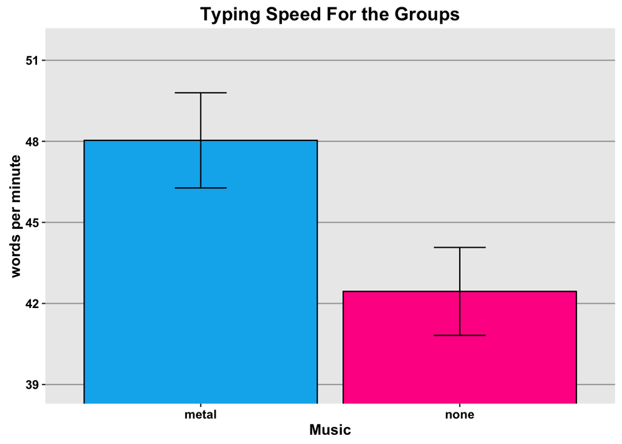

```r
f<-ggplot(temp,aes(x=factor(music),y=means))+
  geom_bar(stat="identity", color="black",
           fill=c("deepskyblue2", "deeppink"))+
  geom_errorbar(aes(ymax=means+sems,
                    ymin=means-sems),
                width=.2)+
  ggtitle("Typing Speed For the Groups")+
  labs(x="Music", y="words per minute")+
  scale_x_discrete(breaks=c("none","metal"),
                   labels=c("none","metal"))+
  theme(plot.title=element_text(size=15,
                                face="bold",
                                vjust=.5))+
  theme(axis.title.x=element_text(size=12,
                                  face="bold",
                                  vjust=-.25))+
  theme(axis.title.y=element_text(size=12,
                                  face="bold",
                                  vjust=.25))+
  theme(axis.text.x=element_text(size=10,
                                 face="bold",
                                 color="black"))+
  theme(axis.text.y=element_text(size=10,
                                 face="bold",
                                 color="black"))+
  coord_cartesian(ylim=c(min(temp$means)-2*max(temp$sems),
                         max(temp$means)+2*max(temp$sems)))+
  theme(panel.border=element_blank(),
        axis.line=element_line())+
  theme(panel.grid.major.x=element_blank())+
  theme(panel.grid.major.y=element_line(color="darkgrey"))+
  theme(panel.grid.minor.y=element_blank())
f
```

Conduct and interpret a two-tailed paired t-test on the data.

```r
t.test(dat$wpm[dat$music=="none"],
       dat$wpm[dat$music=="metal"],
       var.equal=TRUE,
       paired=TRUE)
```

```
##
##  Paired t-test
##
## data:  dat$wpm[dat$music == "none"] and dat$wpm[dat$music == "metal"]
## t = -12.153, df = 31, p-value = 2.51e-13
## alternative hypothesis: true difference in means is not equal to 0
## 95 percent confidence interval:
##  -6.528390 -4.652093
## sample estimates:
## mean of the differences
##               -5.590241
```

Participants in the metal music group typed faster than the participants in the no music group, t(31) = -12.153, p < .05.